# Logistic regression

Week 3, Anton Jyrkiäinen

Dependancies used:

```r
library(dplyr);
library(ggplot2);
library(tidyr);
```

```r
alc <- read.table("http://s3.amazonaws.com/assets.datacamp.com/production/course_2218/datasets/alc.txt", sep = ",", header=TRUE)
```

Variables in the dataset:

```r
names(alc)
```

```
##  [1] "school"     "sex"        "age"        "address"    "famsize"
##  [6] "Pstatus"    "Medu"       "Fedu"       "Mjob"       "Fjob"
## [11] "reason"     "nursery"    "internet"   "guardian"   "traveltime"
## [16] "studytime"  "failures"   "schoolsup"  "famsup"     "paid"
## [21] "activities" "higher"     "romantic"   "famrel"     "freetime"
## [26] "goout"      "Dalc"       "Walc"       "health"     "absences"
## [31] "G1"         "G2"         "G3"         "alc_use"    "high_use"
```

The dataset consists of data collected from school reports and questionnaires from two different Portugese schools regarding the performance in two subjects: mathematics and Portugese.

Link to the data [here](https://archive.ics.uci.edu/ml/machine-learning-databases/00320/) and link to metadata [here](https://archive.ics.uci.edu/ml/datasets/Student+Performance).

Absences, studytime and grades go together quite well when doing analysis of school performance. I expect that absences are positively correlated and studytime and grades negatively correlated with high alcohol use. Gender will probably have no difference in this and will not be statistically significant Therefor the variables to be used are `absences`, `studytime`, `G3` and `sex`.

Barplot of each variable we’re interested in:

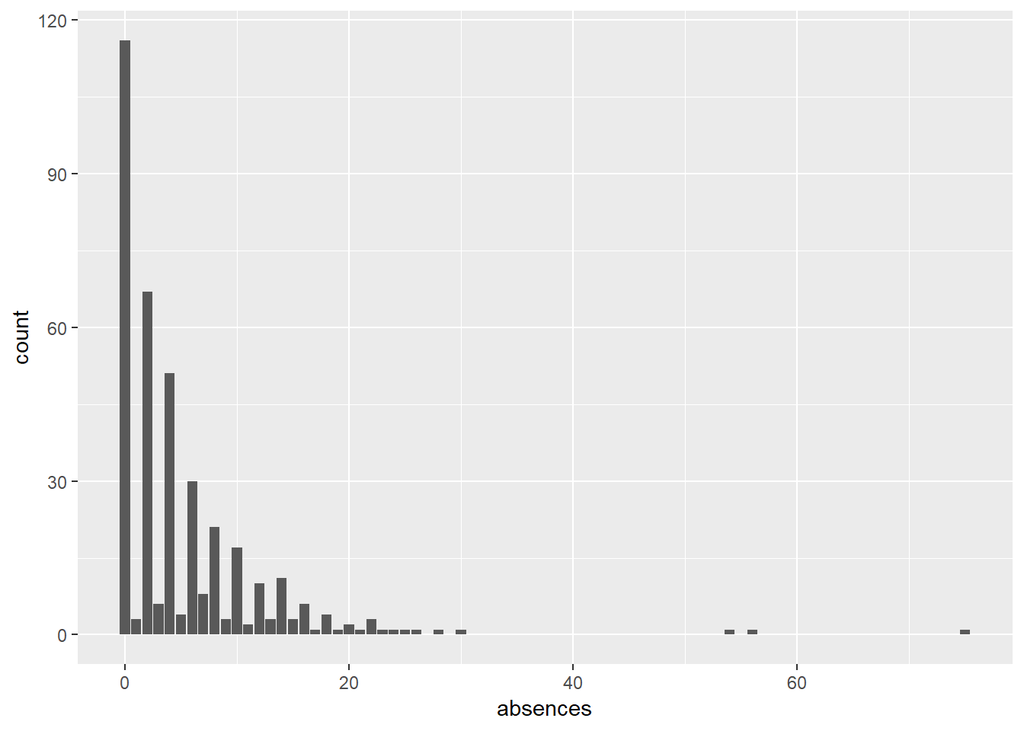

```r
ggplot(data = alc, aes(x = absences)) + geom_bar()
```

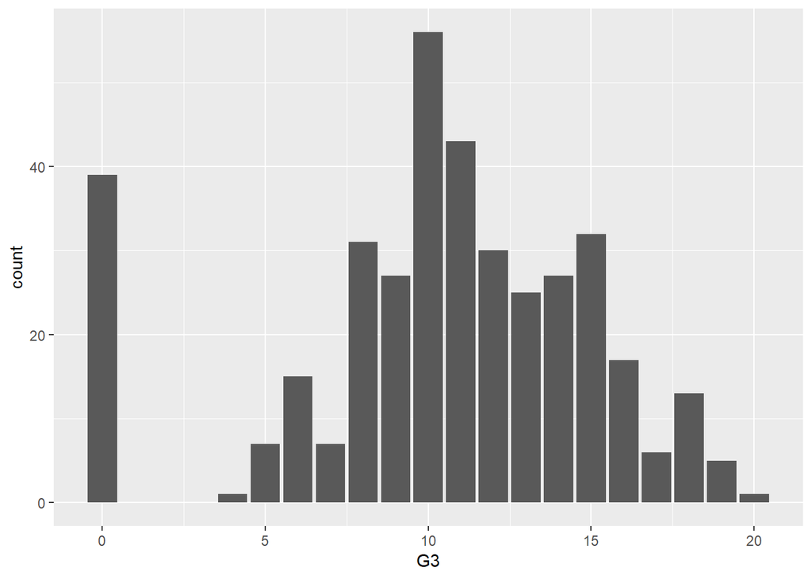

```r
ggplot(data = alc, aes(x = G3)) + geom_bar()
```

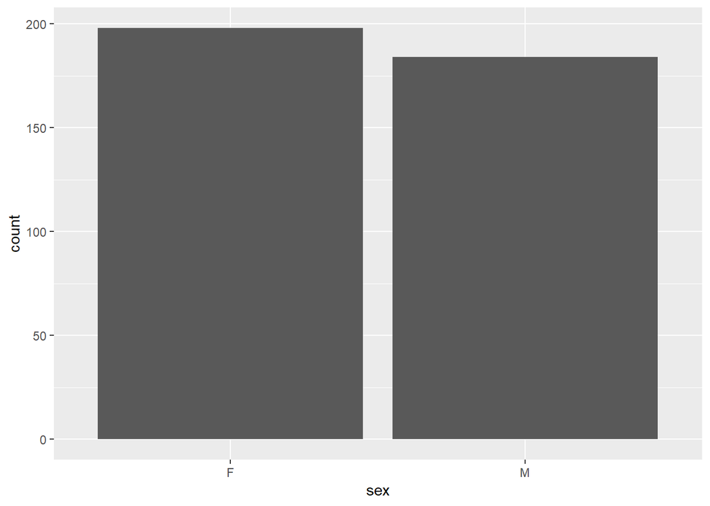

```r
ggplot(data = alc, aes(x = sex)) + geom_bar()
```

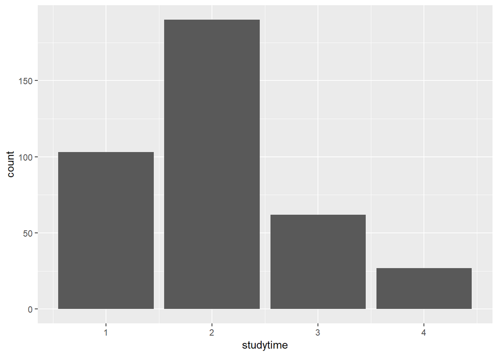

```r
ggplot(data = alc, aes(x = studytime)) + geom_bar()
```

In the barplots we can observe the distribution of the variables we’ve chosen. We can see that it is more common to have none or less absences. Most of the students are getting average or a bit above average grades.There’s also quite large number of students receiving 0 grade. There’s slightly more female students than male students. Majority of the students seem to study less than 2 hours or 2-5 hours weekly.

Boxplots:

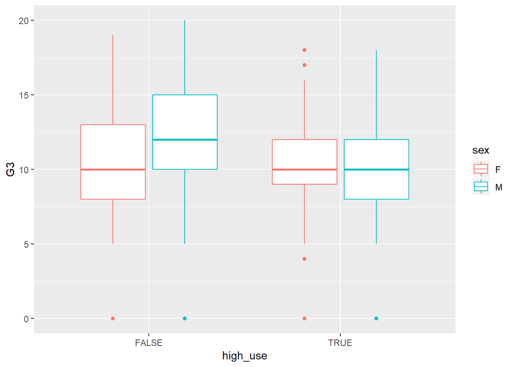

```r
g1 <- ggplot(alc, aes(x = high_use, y = G3, col = sex))
g1 + geom_boxplot()
```

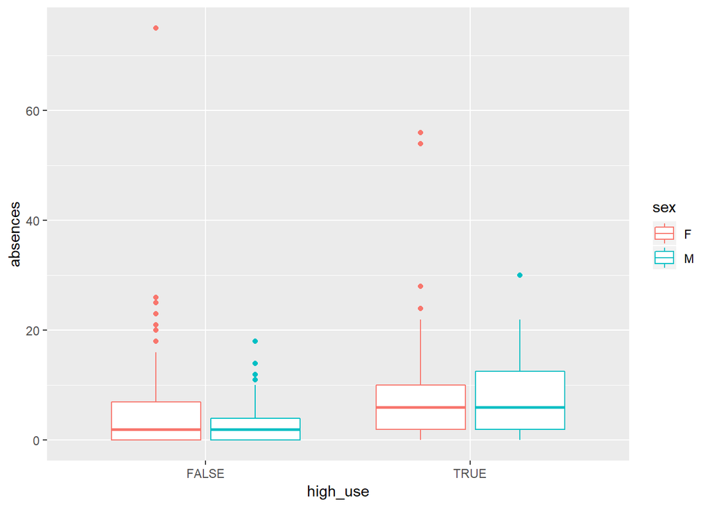

```r
g2 <- ggplot(alc, aes(x = high_use, y = absences, col = sex))
g2 + geom_boxplot()
```

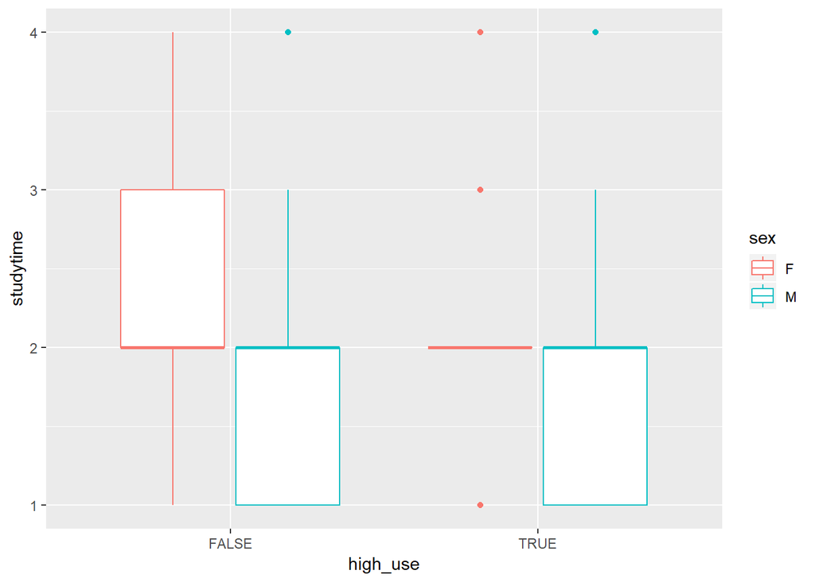

```r
g2 <- ggplot(alc, aes(x = high_use, y = studytime, col = sex))
g2 + geom_boxplot()
```

Grade means by group:

```r
alc %>% group_by(sex, high_use) %>% summarise(count = n(), mean_grade = mean(G3))
```

```
## # A tibble: 4 x 4
## # Groups:   sex [?]
##   sex   high_use count mean_grade
##   <fct> <lgl>    <int>      <dbl>
## 1 F     FALSE      157       9.69
## 2 F     TRUE        41      10.4
## 3 M     FALSE      113      11.6
## 4 M     TRUE        71       9.97
```

Among the female students there’s a grade mean increase of 0.71 when the person is considered to have high use of alcohol. Among the male students there’s a large grade drop of 1.63 points if the student is categorized to the high use of alcohol group.

Absence mean by group:

```r
alc %>% group_by(sex, high_use) %>% summarise(count = n(), mean_absences = mean(absences))
```

```
## # A tibble: 4 x 4
## # Groups:   sex [?]
##   sex   high_use count mean_absences
##   <fct> <lgl>    <int>         <dbl>
## 1 F     FALSE      157          4.97
## 2 F     TRUE        41          8.90
## 3 M     FALSE      113          3.19
## 4 M     TRUE        71          7.41
```

We can observe that the high alcohol use has a negative impact on the absences of the student. With the female students there’s 3.93 more school absences and with the male students the absences are more than doubled.

Study time mean by group:

```r
alc %>% group_by(sex, high_use) %>% summarise(count = n(), mean_studytime = mean(studytime))
```

```
## # A tibble: 4 x 4
## # Groups:   sex [?]
##   sex   high_use count mean_studytime
##   <fct> <lgl>    <int>          <dbl>
## 1 F     FALSE      157           2.34
## 2 F     TRUE        41           2
## 3 M     FALSE      113           1.88
## 4 M     TRUE        71           1.62
```

Average studying times seem also to suffer from high alcohol use with lower mean studying times in both groups.

Summary of logistic regression with our variables and high/low alcohol consumption set as the target variable:

```r
m <- glm(high_use ~ sex + absences + G3 + studytime, data = alc, family = "binomial")
summary(m)
```

```
##
## Call:
## glm(formula = high_use ~ sex + absences + G3 + studytime, family = "binomial",
##     data = alc)
##
## Deviance Residuals:
##     Min       1Q   Median       3Q      Max
## -2.6894  -0.8391  -0.5951   1.1034   2.1852
##
## Coefficients:
##             Estimate Std. Error z value Pr(>|z|)
## (Intercept) -0.64915    0.45507  -1.426 0.153725
## sexM         0.84250    0.25698   3.278 0.001044 **
## absences     0.07076    0.01821   3.887 0.000102 ***
## G3          -0.02575    0.02635  -0.977 0.328574
## studytime   -0.41864    0.16119  -2.597 0.009398 **
## ---
## Signif. codes:  0 '***' 0.001 '**' 0.01 '*' 0.05 '.' 0.1 ' ' 1
##
## (Dispersion parameter for binomial family taken to be 1)
##
##     Null deviance: 462.21  on 381  degrees of freedom
## Residual deviance: 416.74  on 377  degrees of freedom
## AIC: 426.74
##
## Number of Fisher Scoring iterations: 4
```

Odds ratios with their confidence intervals:

```r
OR <- coef(m) %>% exp
CI <- confint(m) %>% exp
cbind(OR, CI)
```

```
##                    OR     2.5 %    97.5 %
## (Intercept) 0.5224889 0.2125860 1.2719337
## sexM        2.3221692 1.4096724 3.8686858
## absences    1.0733272 1.0379854 1.1144115
## G3          0.9745836 0.9257160 1.0267950
## studytime   0.6579430 0.4751282 0.8953331
```

The `OR` column is the exponent of the coefficient which can be interpret as odds ratio between a unit change in the corresponging explanatory variable. Therefor the row `sexM` can be interpret as male students being ~2.3 times more likely to be heavy user of alcohol than the female students.

```r
m <- glm(high_use ~ sex + absences + G3 + studytime, data = alc, family = "binomial")
```

Let’s explore the predictive power of the model:

```r
probabilities <- predict(m, type = "response")
alc <- mutate(alc, probability = probabilities)
alc <- mutate(alc, prediction = probability > 0.5)
```

First we used the predict()-function to get the probability of high use. Then added the predicted probabiliets to `alc` and then alter the table so it has a column `prediction` which has a boolean value as predictor of high use. If the probability was higher than 0.5 the value is set to `TRUE` otherwise `FALSE`.

Let’s look at a confusion matrix:

```r
table(high_use = alc$high_use, prediction = alc$prediction)
```

```
##         prediction
## high_use FALSE TRUE
##    FALSE   262    8
##    TRUE     85   27
```

Tabulate the target variable versus the prediction:

```r
table(high_use = alc$high_use, prediction = alc$prediction) %>% prop.table %>% addmargins
```

```
##         prediction
## high_use      FALSE       TRUE        Sum
##    FALSE 0.68586387 0.02094241 0.70680628
##    TRUE  0.22251309 0.07068063 0.29319372
##    Sum   0.90837696 0.09162304 1.00000000
```